# AAC 6510 Dataset Project

Author

Angela Qian, Nerina Campos, Krystal Lee, Selina Im, Karima Ajahiou

## 1 Quarto

```r
options(repos = c(CRAN = "https://cran.rstudio.com/"))
```

## 2 Introduction to our Dataset

This study explores the most important factors that influence the adoption of shelter animals. By understanding the key characteristics that impact adoption decisions, this analysis aims to provide valuable insights to help animal shelters improve their strategies and increase adoption rates.

[Dataset Link](https://www.kaggle.com/datasets/aaronschlegel/austin-animal-center-shelter-intakes-and-outcomes)

### 2.1 Research Question

How do various animal traits—such as breed, age, sex, intake condition, color, and intake type—affect the likelihood of being adopted from shelters?

### 2.2 Dependent Variables

The dependent variable in this study is:

- Likelihood of Adoption
  - This is a binary outcome that indicates whether an animal was adopted or not:
    - 1 = The animal was adopted.
    - 0 = The animal was not adopted (e.g., transferred to another shelter).

This variable is the central focus of our analysis, as we aim to understand which animal characteristics (independent variables) are associated with a higher likelihood of adoption. By identifying these key factors, we can provide insights to help shelters improve adoption strategies and outcomes.

### 2.3 Independent Variables

The independent variables in this study are the characteristics of the animals that may influence their likelihood of being adopted. These variables were carefully chosen based on shelter data and include the following:

1. Intake Type - Describes how the animal came into the shelter.

- Stray: The animal was found without an owner.
- Public Assist: The animal was brought in through public assistance.
- Owner Surrender: The previous owner gave up the animal.

2. Intake Condition - The physical or medical state of the animal at the time of intake:

- Normal: The animal appeared healthy.
- Injured: The animal had visible injuries.
- Aged: The animal was considered older.

3. Age Upon Intake - The age of the animal when it entered the shelter, measured in years.

5. Breed Type - The breed classification of the animal:

- Popular Family Dog: Includes breeds like Labrador Retrievers and Golden Retrievers that are often considered family-friendly.
- Protective Breed: Breeds known for their protective instincts, such as German Shepherds and Doberman Pinschers.
- High-Energy Breed: Breeds like Huskies and Malamutes that are known for being active.
- Small Cuddly Breed: Small-sized breeds like Chihuahuas and Yorkshire Terriers.

6. Intake Year - The year the animal was taken into the shelter, which helps identify trends over time.

7. Intake as Stray or Public Assist - Binary variables indicating if the animal was a stray or brought in through public assistance.

By analyzing these variables, the study identifies which traits—like breed, age, or condition—are most strongly associated with adoption outcomes. This helps shelters focus on improving the adoption chances for animals that might be overlooked.

## 3 Loading Packages

```r
library(tidyverse)
library(janitor)
library(rio)
library(dplyr)
```

## 4 Running Code

```r
DataAdoptionPets <- import('aac_intakes_outcomes.csv') |>
   clean_names("upper_camel")

head(DataAdoptionPets)
```

```
  AgeUponOutcome AnimalIdOutcome   DateOfBirth OutcomeSubtype     OutcomeType
1       10 years         A006100   7/9/07 0:00                Return to Owner
2        7 years         A006100   7/9/07 0:00                Return to Owner
3        6 years         A006100   7/9/07 0:00                Return to Owner
4       10 years         A047759   4/2/04 0:00        Partner        Transfer
5       16 years         A134067 10/16/97 0:00                Return to Owner
6       15 years         A141142   6/1/98 0:00                Return to Owner
  SexUponOutcome AgeUponOutcomeDays AgeUponOutcomeYears AgeUponOutcomeAgeGroup
1  Neutered Male               3650                  10            (7.5, 10.0]
2  Neutered Male               2555                   7             (5.0, 7.5]
3  Neutered Male               2190                   6             (5.0, 7.5]
4  Neutered Male               3650                  10            (7.5, 10.0]
5  Neutered Male               5840                  16           (15.0, 17.5]
6  Spayed Female               5475                  15           (12.5, 15.0]
  OutcomeDatetime OutcomeMonth OutcomeYear OutcomeMonthyear OutcomeWeekday
```

[output cut: 55 more lines]

## 5 Directed Acrylical Graph (DAG)

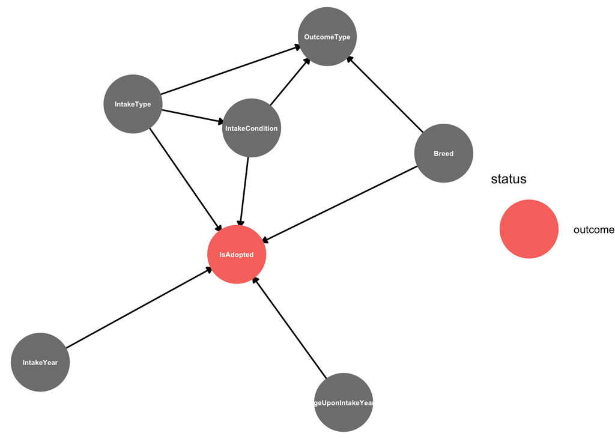

```r
library(ggdag)
library(ggplot2)
set.seed(123)
dag <- dagify(
  IsAdopted ~ Breed + IntakeCondition + IntakeYear + IntakeType + AgeUponIntakeYears,
  IntakeCondition ~ IntakeType,
  OutcomeType ~ IntakeCondition + IntakeType + Breed,
  outcome = "IsAdopted"
)
ggdag_status(dag, node_size = 22, text_size = 2) +
  theme_void()
```

## 6 Cleaning Data

```r
# Cleaning Data for Selected Variables

DataAdoptionPetsYes <- DataAdoptionPets %>% select(OutcomeType, AnimalType, Breed, IntakeCondition, IntakeType, Color, AgeUponIntakeYears, IntakeYear)

# Filtering for Dog's only
filtered_data <- DataAdoptionPetsYes %>% filter(grepl("Dog", AnimalType))

filtered_data <- DataAdoptionPetsYes %>%
  filter(str_trim(OutcomeType) %in% c("Adoption", "Transfer"))

# View the filtered data
head(filtered_data)
```

```
  OutcomeType AnimalType                     Breed IntakeCondition
1    Transfer        Dog                 Dachshund          Normal
2    Transfer        Cat    American Shorthair Mix          Normal
3    Adoption        Dog             Dachshund Mix          Normal
4    Adoption        Dog       Chihuahua Shorthair            Aged
5    Adoption        Dog Labrador Retriever/Beagle          Normal
6    Transfer        Dog           Rat Terrier Mix          Normal
       IntakeType             Color AgeUponIntakeYears IntakeYear
1 Owner Surrender          Tricolor                 10       2014
2           Stray Brown Tabby/White                 14       2014
3 Owner Surrender         Black/Tan                 16       2013
4   Public Assist         Tan/Black                 17       2016
5           Stray       Sable/White                 15       2015
6           Stray        Gray/White                 15       2016
```